# Risk Analysis

Let’s further analyze exactly how early or late are the loans being paid?

```r
head(lcdf[, c("last_pymnt_d", "issue_d")])
```

```
## # A tibble: 6 × 2
##   last_pymnt_d issue_d
##   <chr>        <dttm>
## 1 Jul-2016     2015-05-01 00:00:00
## 2 Jun-2017     2015-07-01 00:00:00
## 3 Nov-2017     2014-11-01 00:00:00
## 4 Aug-2015     2014-03-01 00:00:00
## 5 Nov-2017     2015-04-01 00:00:00
## 6 Mar-2016     2014-01-01 00:00:00
```

```r
# Bringing them to a consistent format
lcdf$last_pymnt_d<-paste(lcdf$last_pymnt_d, "-01", sep = "")
lcdf$last_pymnt_d<-parse_date_time(lcdf$last_pymnt_d,  "myd")

#Check their format now
head(lcdf[, c("last_pymnt_d", "issue_d")])
```

```
## # A tibble: 6 × 2
##   last_pymnt_d        issue_d
##   <dttm>              <dttm>
## 1 2016-07-01 00:00:00 2015-05-01 00:00:00
## 2 2017-06-01 00:00:00 2015-07-01 00:00:00
## 3 2017-11-01 00:00:00 2014-11-01 00:00:00
## 4 2015-08-01 00:00:00 2014-03-01 00:00:00
## 5 2017-11-01 00:00:00 2015-04-01 00:00:00
## 6 2016-03-01 00:00:00 2014-01-01 00:00:00
```

```r
# Creating actual term column - If loan is charged off by default - 3 years
lcdf$actualTerm <- ifelse(lcdf$loan_status=="Fully Paid", as.duration(lcdf$issue_d  %--% lcdf$last_pymnt_d)/dyears(1), 3)

# We know using simple interest Total =  principle + pnr/100
# Hence r = (Total - principle)/principle * 100/n

# Then, considering this actual term, the actual annual return is

lcdf$actualReturn <- ifelse(lcdf$actualTerm>0, ((lcdf$total_pymnt -lcdf$funded_amnt)/lcdf$funded_amnt)*(1/lcdf$actualTerm)*100, 0)

lcdf %>% select(loan_status, int_rate, funded_amnt, total_pymnt, annRet, actualTerm, issue_d,last_pymnt_d) %>%  head()
```

```
## # A tibble: 6 × 8
##   loan_status int_rate funded_amnt total_py…¹ annRet actua…² issue_d
##   <chr>          <dbl>       <dbl>      <dbl>  <dbl>   <dbl> <dttm>
## 1 Fully Paid      5.32       28000     29437.   1.71    1.17 2015-05-01 00:00:00
## 2 Fully Paid     13.3         6150      7311.   6.29    1.92 2015-07-01 00:00:00
## 3 Fully Paid     15.0         7200      8972.   8.20    3.00 2014-11-01 00:00:00
## 4 Fully Paid     15.3         4750      5611.   6.04    1.42 2014-03-01 00:00:00
## 5 Fully Paid     12.7         5000      6009.   6.73    2.59 2015-04-01 00:00:00
## 6 Fully Paid     15.0         9600     11748.   7.46    2.16 2014-01-01 00:00:00
## # … with 1 more variable: last_pymnt_d <dttm>, and abbreviated variable names
## #   ¹total_pymnt, ²actualTerm
```

```r
# Checking the same for charged off loans
lcdf %>% select(loan_status, int_rate, funded_amnt, total_pymnt, annRet, actualTerm, actualReturn) %>% filter(loan_status=="Charged Off") %>% head()
```

```
## # A tibble: 6 × 7
##   loan_status int_rate funded_amnt total_pymnt annRet actualTerm actualReturn
##   <chr>          <dbl>       <dbl>       <dbl>  <dbl>      <dbl>        <dbl>
## 1 Charged Off     16.0        8000       5936.  -8.60          3        -8.60
## 2 Charged Off     13.7       27500       4704. -27.6           3       -27.6
## 3 Charged Off     16.5       11625       6543. -14.6           3       -14.6
## 4 Charged Off     13.0        5600       6114.   3.06          3         3.06
## 5 Charged Off     16.6        3500       3711.   2.01          3         2.01
## 6 Charged Off     12.0       25000       7314. -23.6           3       -23.6
```

Let’s find out actual return with respect to actual term.

```r
# For cost-based performance, we may want to see the average interest rate, and the average of proportion of loan amount paid back, grouped by loan_status

lcdf%>% group_by(loan_status) %>% summarise(  meanintRate=mean(int_rate), meanRet=mean((total_pymnt-funded_amnt)/funded_amnt),meanRetPer=mean((total_pymnt-funded_amnt)/funded_amnt)*100, sumTotalpymt = sum(total_pymnt), sumFundedamnt = sum(funded_amnt), term=mean(actualTerm)  )
```

```
## # A tibble: 2 × 7
##   loan_status meanintRate meanRet meanRetPer sumTotalpymt sumFundedamnt  term
##   <chr>             <dbl>   <dbl>      <dbl>        <dbl>         <dbl> <dbl>
## 1 Charged Off        13.9  -0.359      -35.9   107801040.     168999125  3
## 2 Fully Paid         11.7   0.154       15.4  1271091404.    1104497150  2.13
```

```r
# Checking the same by grade along with loan status

lcdf%>% group_by(loan_status, grade) %>% summarise(  intRate=mean(int_rate),meanRet=mean((total_pymnt-funded_amnt)/funded_amnt),
meanRetPer=mean((total_pymnt-funded_amnt)/funded_amnt)*100,sumTotalpymt = sum(total_pymnt), sumFundedamnt = sum(funded_amnt), term=mean(actualTerm)   )
```

```
## # A tibble: 14 × 8
## # Groups:   loan_status [2]
##    loan_status grade intRate meanRet meanRetPer sumTotalpymt sumFundedamnt  term
##    <chr>       <chr>   <dbl>   <dbl>      <dbl>        <dbl>         <dbl> <dbl>
##  1 Charged Off A        7.44 -0.347      -34.7     10551097.      16182850  3
##  2 Charged Off B       10.9  -0.346      -34.6     30252911.      46221175  3
##  3 Charged Off C       13.9  -0.359      -35.9     36394725.      57214150  3
##  4 Charged Off D       17.2  -0.371      -37.1     21511774.      34618525  3
##  5 Charged Off E       19.8  -0.381      -38.1      7390448.      12117275  3
##  6 Charged Off F       24.1  -0.357      -35.7      1534358.       2344325  3
##  7 Charged Off G       26.4  -0.432      -43.2       165728.        300825  3
##  8 Fully Paid  A        7.16  0.0951       9.51   341332406.     311443175  2.20
##  9 Fully Paid  B       10.7   0.142       14.2    436933918.     382261400  2.15
## 10 Fully Paid  C       13.8   0.181       18.1    310248814.     262517900  2.09
## 11 Fully Paid  D       17.2   0.222       22.2    139263468.     113957300  2.03
## 12 Fully Paid  E       20.0   0.257       25.7     36885764.      29451525  2.01
## 13 Fully Paid  F       23.9   0.319       31.9      5581142.       4220600  2.09
## 14 Fully Paid  G       26.4   0.318       31.8       845893.        645250  1.91
```

```r
# For Fully Paid loans, is the average value of totRet what you'd expect, considering the average value for intRate?


lcdf %>% group_by(loan_status) %>% summarise(avgInt=mean(int_rate), avgRet=mean(actualReturn),avgTerm=mean(actualTerm))
```

```
## # A tibble: 2 × 4
##   loan_status avgInt avgRet avgTerm
##   <chr>        <dbl>  <dbl>   <dbl>
## 1 Charged Off   13.9 -12.0     3
## 2 Fully Paid    11.7   8.02    2.13
```

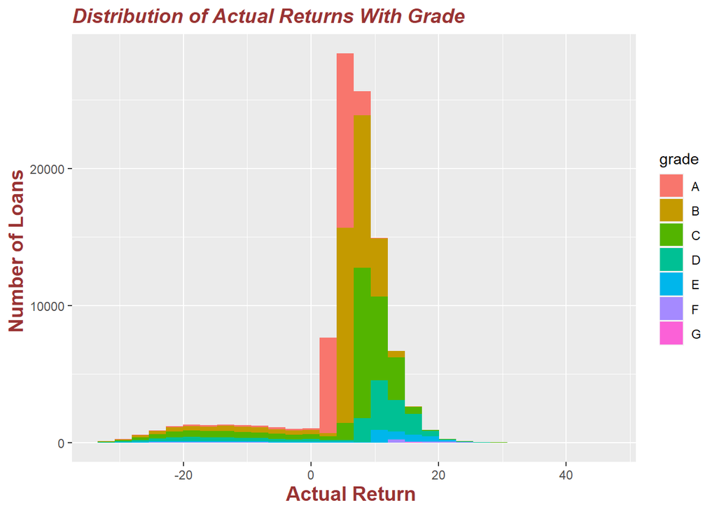

```r
ggplot(lcdf, aes( x = actualReturn)) + geom_histogram(aes(fill=grade)) + ggtitle("Distribution of Actual Returns With Grade") + xlab("Actual Return ") + ylab("Number of Loans ") + theme(plot.title = element_text(color="#993333", size=14, face="bold.italic"), axis.title.x = element_text(color="#993333", size=14, face="bold"), axis.title.y = element_text(color="#993333", size=14, face="bold"))
```

Let’s check distribution of actual term

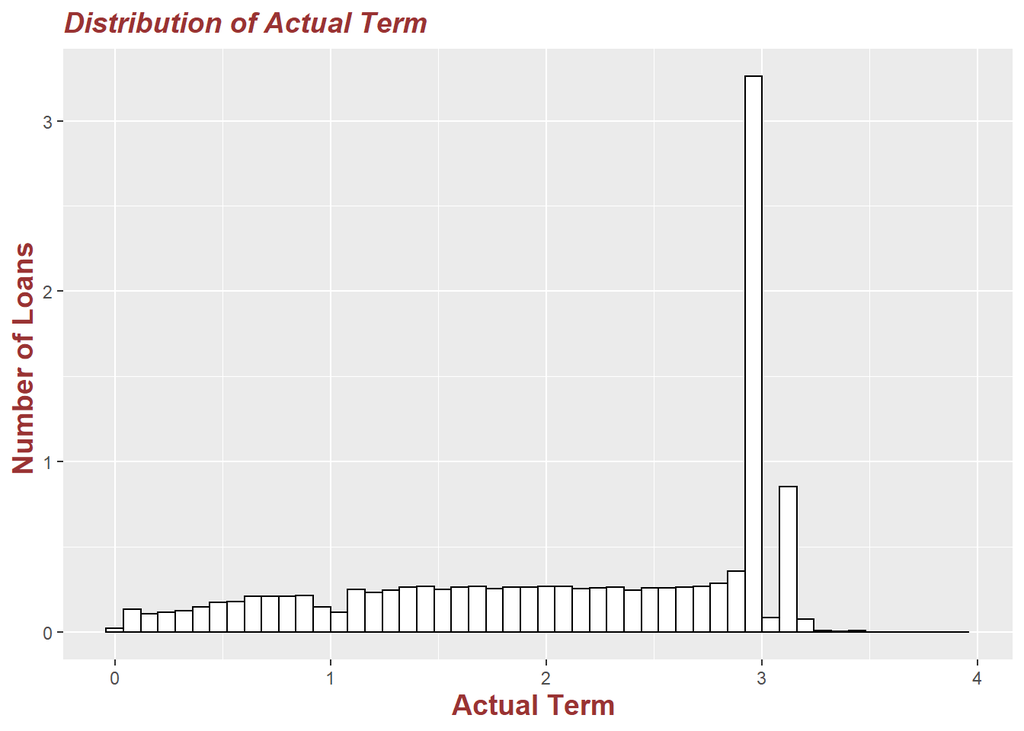

```r
ggplot(lcdf %>% filter(loan_status=='Fully Paid'), aes( x = actualTerm)) + geom_histogram(aes(y=..density..), colour="black", fill="white", bins=50) +ggtitle("Distribution of Actual Term ") + xlab("Actual Term ") + ylab("Number of Loans ") + theme(plot.title = element_text(color="#993333", size=14, face="bold.italic"), axis.title.x = element_text(color="#993333", size=14, face="bold"), axis.title.y = element_text(color="#993333", size=14, face="bold"))
```

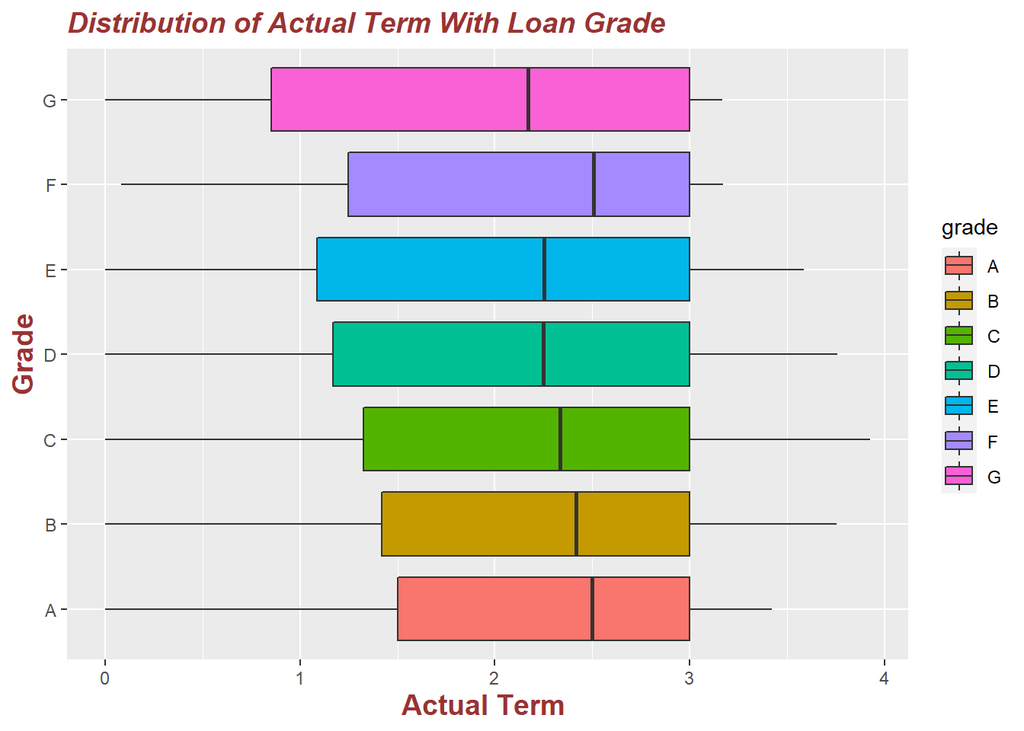

```r
ggplot(lcdf %>% filter(loan_status=='Fully Paid'), aes( x = actualTerm, y=grade)) + geom_boxplot(aes(fill=grade)) + ggtitle("Distribution of Actual Term With Loan Grade ")+
xlab("Actual Term ") + ylab("Grade") + theme(plot.title = element_text(color="#993333", size=14, face="bold.italic"), axis.title.x = element_text(color="#993333", size=14, face="bold"), axis.title.y = element_text(color="#993333", size=14, face="bold"))
```

Derived attributes

```r
lcdf$propSatisBankcardAccts <- ifelse(lcdf$num_bc_tl>0, lcdf$num_bc_sats/lcdf$num_bc_tl, 0)

# Let us look at the column created

summary(lcdf$propSatisBankcardAccts)
```

```
##    Min. 1st Qu.  Median    Mean 3rd Qu.    Max.
##  0.0000  0.4286  0.6000  0.6161  0.8000  1.0000
```

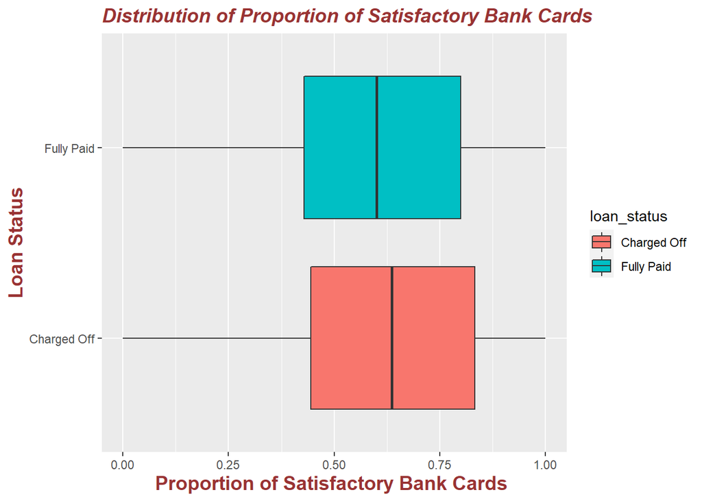

```r
# Plot
ggplot(lcdf, aes( x = propSatisBankcardAccts, y=loan_status)) + geom_boxplot(aes(fill=loan_status)) + ggtitle("Distribution of Proportion of Satisfactory Bank Cards") +
xlab("Proportion of Satisfactory Bank Cards ") + ylab(" Loan Status ") + theme(plot.title = element_text(color="#993333", size=14, face="bold.italic"), axis.title.x = element_text(color="#993333", size=14, face="bold"), axis.title.y = element_text(color="#993333", size=14, face="bold"))
```

```r
#Another one - lets calculate the length of borrower's history

#  i.e time between earliest_cr_line - open of current credit line. The month the borrowers earliers
# issue_d

# Correcting the date format
lcdf$earliest_cr_line<-paste(lcdf$earliest_cr_line, "-01", sep = "")

lcdf$earliest_cr_line<-parse_date_time(lcdf$earliest_cr_line, "myd")

lcdf$earliest_cr_line %>% head()
```

```
## [1] "1994-12-01 UTC" "1988-04-01 UTC" "1988-08-01 UTC" "1984-02-01 UTC"
## [5] "2000-07-01 UTC" "2005-01-01 UTC"
```

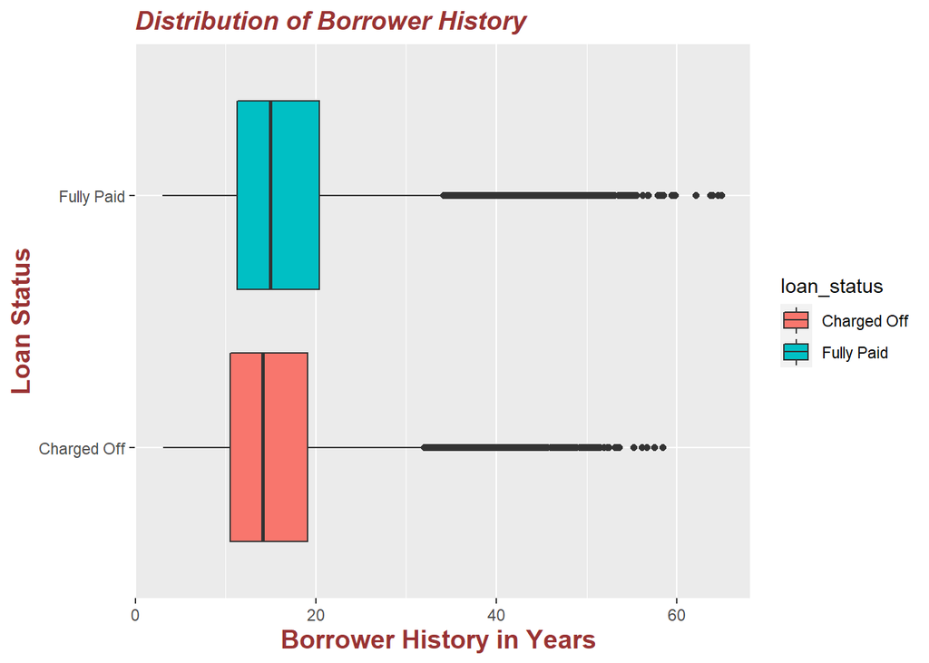

```r
lcdf$borrHistory <- as.duration(lcdf$earliest_cr_line %--% lcdf$issue_d  ) / dyears(1)


ggplot(lcdf, aes( x = borrHistory, y=loan_status)) + geom_boxplot(aes(fill=loan_status)) +
xlab("Borrower History in Years ") + ylab("Loan Status")+ggtitle("Distribution of Borrower History") + theme(plot.title = element_text(color="#993333", size=14, face="bold.italic"), axis.title.x = element_text(color="#993333", size=14, face="bold"), axis.title.y = element_text(color="#993333", size=14, face="bold"))
```

```r
#Another new attribute: ratio of openAccounts to totalAccounts


lcdf$openAccRatio <- ifelse(lcdf$total_acc>0, lcdf$open_acc/lcdf$total_acc, 0)


summary(lcdf$openAccRatio)
```

```
##    Min. 1st Qu.  Median    Mean 3rd Qu.    Max.
##  0.0000  0.3704  0.4800  0.5014  0.6154  1.0000
```

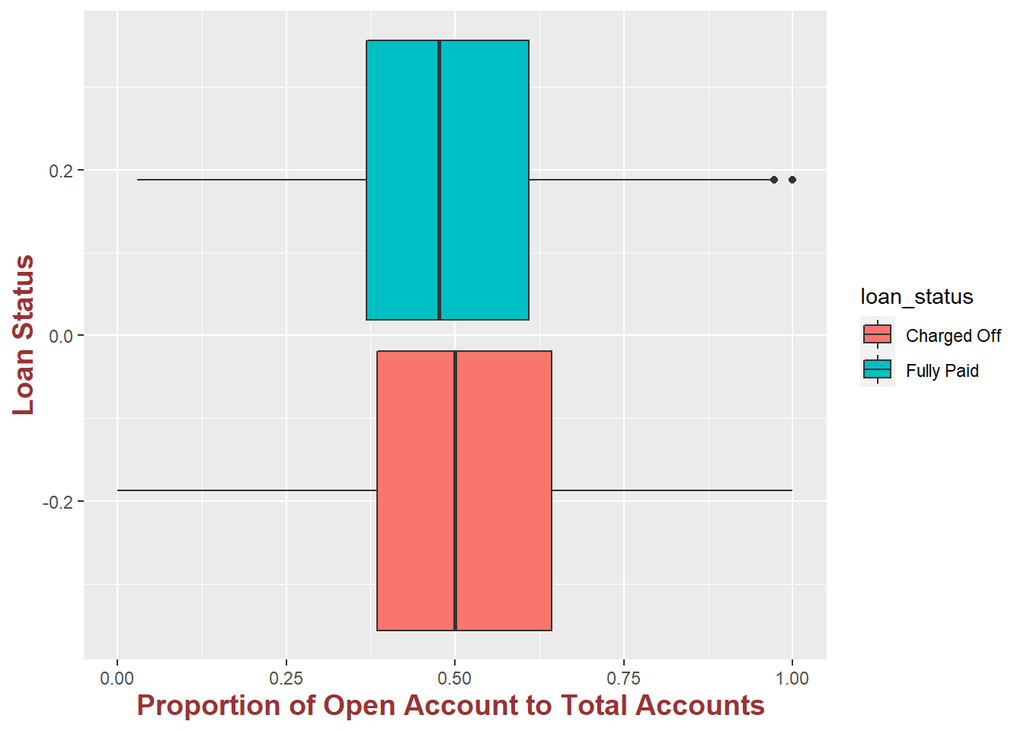

```r
 #   Min. 1st Qu.  Median    Mean 3rd Qu.    Max.
 # 0.0000  0.3704  0.4815  0.5017  0.6154  1.0000

ggplot(lcdf, aes( x = openAccRatio)) + geom_boxplot(aes(fill=loan_status)) +
xlab("Proportion of Open Account to Total Accounts ") + ylab(" Loan Status ") + theme(plot.title = element_text(color="#993333", size=14, face="bold.italic"), axis.title.x = element_text(color="#993333", size=14, face="bold"), axis.title.y = element_text(color="#993333", size=14, face="bold"))
```

```r
#does LC-assigned loan grade vary by borrHistory?

lcdf %>% group_by(grade) %>% summarise(avgBorrHist=mean(borrHistory))
```

```
## # A tibble: 7 × 2
##   grade avgBorrHist
##   <chr>       <dbl>
## 1 A            18.2
## 2 B            16.7
## 3 C            15.5
## 4 D            14.9
## 5 E            14.4
## 6 F            13.5
## 7 G            11.4
```

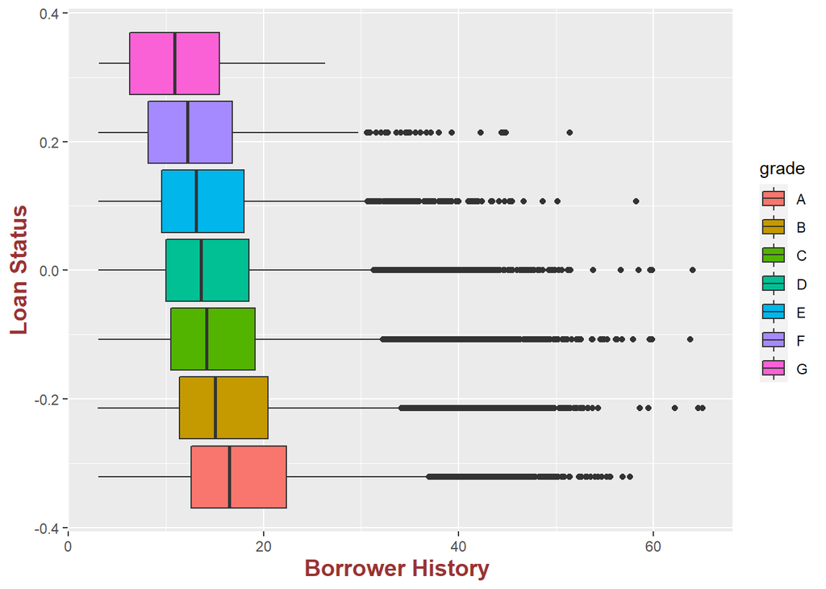

```r
ggplot(lcdf, aes( x = borrHistory)) + geom_boxplot(aes(fill=grade)) +
xlab("Borrower History ") + ylab(" Loan Status ") + theme(plot.title = element_text(color="#993333", size=14, face="bold.italic"), axis.title.x = element_text(color="#993333", size=14, face="bold"), axis.title.y = element_text(color="#993333", size=14, face="bold"))
```

```r
lcdf %>% group_by(grade) %>% summarise(avgBorrHist=mean(borrHistory), minBorrHist=min(borrHistory), maxBorrHist = max(borrHistory), medianBorrHist=median(borrHistory))
```

```
## # A tibble: 7 × 5
##   grade avgBorrHist minBorrHist maxBorrHist medianBorrHist
##   <chr>       <dbl>       <dbl>       <dbl>          <dbl>
## 1 A            18.2        3.08        57.6           16.5
## 2 B            16.7        3.00        65.0           15.1
## 3 C            15.5        3.08        63.8           14.2
## 4 D            14.9        3.08        64             13.6
## 5 E            14.4        3.08        58.3           13.1
## 6 F            13.5        3.08        51.4           12.2
## 7 G            11.4        3.16        26.3           10.9
```

Converting character variables

```r
#glimpse(lcdf)

#  there are a few character type variables - grade, sub_grade, verification_status,....
#   We can  convert all of these to factor

lcdf <- lcdf %>% mutate_if(is.character, as.factor)

#Checking the datatype after conversion

#glimpse(lcdf)
```

Data Leakage Concept of leakage - It is the use of information in the model training process which would not be expected to be available at prediction time, causing the predictive scores (metrics) to overestimate the model’s utility when run in a production environment.Reference - https://en.wikipedia.org/wiki/Leakage_(machine_learning)#:~:text=In%20statistics%20and%20machine%20learning,when%20run%20in%20a%20production

```r
#Identified the variables you want to remove

varsToRemove = c('funded_amnt_inv', 'term', 'emp_title', 'pymnt_plan', 'earliest_cr_line', 'title', 'zip_code', 'addr_state', 'out_prncp', 'out_prncp_inv', 'total_pymnt_inv', 'total_rec_prncp', 'total_rec_int', 'total_rec_late_fee', 'recoveries', 'collection_recovery_fee', 'last_credit_pull_d', 'policy_code', 'disbursement_method', 'debt_settlement_flag',  'settlement_term', 'application_type')

lcdf <- lcdf %>% select(-all_of(varsToRemove))

#Drop all the variables with names starting with "hardship" -- as they can cause leakage, unknown at the time when the loan was given.

#First checking before dropping

lcdf %>% select(starts_with("hardship"))
```

```
## # A tibble: 99,994 × 12
##    hardship_flag hards…¹ hards…² hards…³ hards…⁴ hards…⁵ hards…⁶ hards…⁷ hards…⁸
##    <fct>         <lgl>   <lgl>   <lgl>   <lgl>   <lgl>   <lgl>   <lgl>   <lgl>
##  1 N             NA      NA      NA      NA      NA      NA      NA      NA
##  2 N             NA      NA      NA      NA      NA      NA      NA      NA
##  3 N             NA      NA      NA      NA      NA      NA      NA      NA
##  4 N             NA      NA      NA      NA      NA      NA      NA      NA
##  5 N             NA      NA      NA      NA      NA      NA      NA      NA
##  6 N             NA      NA      NA      NA      NA      NA      NA      NA
##  7 N             NA      NA      NA      NA      NA      NA      NA      NA
##  8 N             NA      NA      NA      NA      NA      NA      NA      NA
##  9 N             NA      NA      NA      NA      NA      NA      NA      NA
## 10 N             NA      NA      NA      NA      NA      NA      NA      NA
## # … with 99,984 more rows, 3 more variables: hardship_loan_status <lgl>,
## #   hardship_payoff_balance_amount <lgl>, hardship_last_payment_amount <lgl>,
## #   and abbreviated variable names ¹hardship_type, ²hardship_reason,
## #   ³hardship_status, ⁴hardship_amount, ⁵hardship_start_date,
## #   ⁶hardship_end_date, ⁷hardship_length, ⁸hardship_dpd
```

```r
# Dropping

lcdf <- lcdf %>% select(-starts_with("hardship"))

#similarly, all variable starting with "settlement", these are happening after disbursement

lcdf %>% select(starts_with('settlement'))
```

```
## # A tibble: 99,994 × 4
##    settlement_status settlement_date settlement_amount settlement_percentage
##    <lgl>             <lgl>           <lgl>             <lgl>
##  1 NA                NA              NA                NA
##  2 NA                NA              NA                NA
##  3 NA                NA              NA                NA
##  4 NA                NA              NA                NA
##  5 NA                NA              NA                NA
##  6 NA                NA              NA                NA
##  7 NA                NA              NA                NA
##  8 NA                NA              NA                NA
##  9 NA                NA              NA                NA
## 10 NA                NA              NA                NA
## # … with 99,984 more rows
```

```r
# 4 columns

#Dropping them

lcdf <- lcdf %>% select(-starts_with("settlement"))

# Additional Leakage variables - based on our understanding


varsToRemove2 <- c("last_pymnt_d", "last_pymnt_amnt", "issue_d",'next_pymnt_d', 'deferral_term', 'payment_plan_start_date', 'debt_settlement_flag_date'  )


# last_pymnt_d, last_pymnt_amnt, next_pymnt_d, deferral_term, payment_plan_start_date, debt_settlement_flag_date

lcdf <- lcdf %>% select(-all_of(varsToRemove2))
```

Understanding the leakage is very important in the concept of Data Mining where we will be going ahead to predict models based on the training data. The models will be well trained if we use the leakage variable, however when we get unseen set of data the prediction will be poor as they wont be having values of these variables

Missing Values

Potential reasons for missing values in different variables? Are some of the missing values actually ‘zeros’ which are not recorded in the data? Is missing-ness informative in some way? Are there, for example, more/less defaults for cases where values on the attribute are missing

```r
# Dropping columns with all n/a

lcdf %>% select_if(function(x){  all(is.na(x)) } ) # Checking what are those columns
```

```
## # A tibble: 99,994 × 19
##    id    member_id url   desc  annual_…¹ dti_j…² verif…³ revol…⁴ sec_a…⁵ sec_a…⁶
##    <lgl> <lgl>     <lgl> <lgl> <lgl>     <lgl>   <lgl>   <lgl>   <lgl>   <lgl>
##  1 NA    NA        NA    NA    NA        NA      NA      NA      NA      NA
##  2 NA    NA        NA    NA    NA        NA      NA      NA      NA      NA
##  3 NA    NA        NA    NA    NA        NA      NA      NA      NA      NA
##  4 NA    NA        NA    NA    NA        NA      NA      NA      NA      NA
##  5 NA    NA        NA    NA    NA        NA      NA      NA      NA      NA
##  6 NA    NA        NA    NA    NA        NA      NA      NA      NA      NA
##  7 NA    NA        NA    NA    NA        NA      NA      NA      NA      NA
##  8 NA    NA        NA    NA    NA        NA      NA      NA      NA      NA
##  9 NA    NA        NA    NA    NA        NA      NA      NA      NA      NA
## 10 NA    NA        NA    NA    NA        NA      NA      NA      NA      NA
## # … with 99,984 more rows, 9 more variables: sec_app_mort_acc <lgl>,
## #   sec_app_open_acc <lgl>, sec_app_revol_util <lgl>,
## #   sec_app_open_act_il <lgl>, sec_app_num_rev_accts <lgl>,
## #   sec_app_chargeoff_within_12_mths <lgl>,
## #   sec_app_collections_12_mths_ex_med <lgl>,
## #   sec_app_mths_since_last_major_derog <lgl>,
## #   orig_projected_additional_accrued_interest <lgl>, and abbreviated …
```

```r
lcdf <- lcdf %>% select_if(function(x){ ! all(is.na(x)) } ) # Dropping

# Finding names of columns which has atleast 1 missing values


names(lcdf)[colSums(is.na(lcdf)) > 0]
```

```
##  [1] "mths_since_last_delinq"         "mths_since_last_record"
##  [3] "revol_util"                     "mths_since_last_major_derog"
##  [5] "open_acc_6m"                    "open_act_il"
##  [7] "open_il_12m"                    "open_il_24m"
##  [9] "mths_since_rcnt_il"             "total_bal_il"
## [11] "il_util"                        "open_rv_12m"
## [13] "open_rv_24m"                    "max_bal_bc"
## [15] "all_util"                       "inq_fi"
## [17] "total_cu_tl"                    "inq_last_12m"
## [19] "avg_cur_bal"                    "bc_open_to_buy"
## [21] "bc_util"                        "mo_sin_old_il_acct"
## [23] "mths_since_recent_bc"           "mths_since_recent_bc_dlq"
## [25] "mths_since_recent_inq"          "mths_since_recent_revol_delinq"
## [27] "num_rev_accts"                  "num_tl_120dpd_2m"
## [29] "pct_tl_nvr_dlq"                 "percent_bc_gt_75"
```

```r
# Finding proportion

options(scipen=999) # To not use scientific notation

colMeans(is.na(lcdf))[colMeans(is.na(lcdf))>0]
```

```
##         mths_since_last_delinq         mths_since_last_record
##                   0.4992199532                   0.8242294538
##                     revol_util    mths_since_last_major_derog
##                   0.0004100246                   0.7199531972
##                    open_acc_6m                    open_act_il
##                   0.9731283877                   0.9731283877
##                    open_il_12m                    open_il_24m
##                   0.9731283877                   0.9731283877
##             mths_since_rcnt_il                   total_bal_il
##                   0.9739284357                   0.9731283877
##                        il_util                    open_rv_12m
##                   0.9769386163                   0.9731283877
##                    open_rv_24m                     max_bal_bc
##                   0.9731283877                   0.9731283877
##                       all_util                         inq_fi
##                   0.9731283877                   0.9731283877
##                    total_cu_tl                   inq_last_12m
##                   0.9731283877                   0.9731283877
##                    avg_cur_bal                 bc_open_to_buy
##                   0.0000200012                   0.0096405784
##                        bc_util             mo_sin_old_il_acct
##                   0.0104406264                   0.0361921715
##           mths_since_recent_bc       mths_since_recent_bc_dlq
##                   0.0091105466                   0.7433145989
##          mths_since_recent_inq mths_since_recent_revol_delinq
##                   0.1061263676                   0.6474888493
##                  num_rev_accts               num_tl_120dpd_2m
##                   0.0000100006                   0.0382422945
##                 pct_tl_nvr_dlq               percent_bc_gt_75
##                   0.0001600096                   0.0103406204
```

```r
# Finding the columns which have more than 60% missing values

names(lcdf)[colMeans(is.na(lcdf))>0.6]
```

```
##  [1] "mths_since_last_record"         "mths_since_last_major_derog"
##  [3] "open_acc_6m"                    "open_act_il"
##  [5] "open_il_12m"                    "open_il_24m"
##  [7] "mths_since_rcnt_il"             "total_bal_il"
##  [9] "il_util"                        "open_rv_12m"
## [11] "open_rv_24m"                    "max_bal_bc"
## [13] "all_util"                       "inq_fi"
## [15] "total_cu_tl"                    "inq_last_12m"
## [17] "mths_since_recent_bc_dlq"       "mths_since_recent_revol_delinq"
```

```r
nm<-names(lcdf)[colMeans(is.na(lcdf))>0.6]
lcdf <- lcdf %>% select(-all_of(nm))

#Impute missing values for remaining variables which have missing values
# - first get the columns with missing values

colMeans(is.na(lcdf))[colMeans(is.na(lcdf))>0]
```

```
## mths_since_last_delinq             revol_util            avg_cur_bal
##           0.4992199532           0.0004100246           0.0000200012
##         bc_open_to_buy                bc_util     mo_sin_old_il_acct
##           0.0096405784           0.0104406264           0.0361921715
##   mths_since_recent_bc  mths_since_recent_inq          num_rev_accts
##           0.0091105466           0.1061263676           0.0000100006
##       num_tl_120dpd_2m         pct_tl_nvr_dlq       percent_bc_gt_75
##           0.0382422945           0.0001600096           0.0103406204
```

```r
nm<- names(lcdf)[colSums(is.na(lcdf))>0]

summary(lcdf[, nm])
```

```
##  mths_since_last_delinq   revol_util      avg_cur_bal     bc_open_to_buy
##  Min.   :  0.00         Min.   :  0.00   Min.   :     0   Min.   :     0
##  1st Qu.: 15.00         1st Qu.: 36.20   1st Qu.:  2791   1st Qu.:  1203
##  Median : 31.00         Median : 54.10   Median :  6311   Median :  3893
##  Mean   : 33.94         Mean   : 53.75   Mean   : 12469   Mean   :  9046
##  3rd Qu.: 50.00         3rd Qu.: 71.80   3rd Qu.: 17266   3rd Qu.: 10602
##  Max.   :188.00         Max.   :153.70   Max.   :395953   Max.   :332178
##  NA's   :49919          NA's   :41       NA's   :2        NA's   :964
##     bc_util       mo_sin_old_il_acct mths_since_recent_bc mths_since_recent_inq
##  Min.   :  0.00   Min.   :  0        Min.   :  0.0        Min.   : 0.000
##  1st Qu.: 42.30   1st Qu.: 96        1st Qu.:  6.0        1st Qu.: 2.000
##  Median : 66.20   Median :128        Median : 14.0        Median : 5.000
##  Mean   : 62.45   Mean   :125        Mean   : 24.5        Mean   : 6.908
##  3rd Qu.: 86.20   3rd Qu.:152        3rd Qu.: 29.0        3rd Qu.:10.000
##  Max.   :188.80   Max.   :640        Max.   :616.0        Max.   :24.000
##  NA's   :1044     NA's   :3619       NA's   :911          NA's   :10612
##  num_rev_accts   num_tl_120dpd_2m pct_tl_nvr_dlq   percent_bc_gt_75
##  Min.   : 2.00   Min.   :0.000    Min.   : 20.00   Min.   :  0.00
##  1st Qu.: 9.00   1st Qu.:0.000    1st Qu.: 91.00   1st Qu.: 16.70
##  Median :13.00   Median :0.000    Median : 97.80   Median : 50.00
##  Mean   :14.76   Mean   :0.001    Mean   : 94.05   Mean   : 48.03
##  3rd Qu.:19.00   3rd Qu.:0.000    3rd Qu.:100.00   3rd Qu.: 75.00
##  Max.   :87.00   Max.   :2.000    Max.   :100.00   Max.   :100.00
##  NA's   :1       NA's   :3824     NA's   :16       NA's   :1034
```

```r
# Replacing values - adding median values

lcdf<- lcdf %>% replace_na(list(mths_since_last_delinq=median(lcdf$mths_since_last_delinq, na.rm=TRUE), bc_open_to_buy=median(lcdf$bc_open_to_buy, na.rm=TRUE), mo_sin_old_il_acct=median(lcdf$mo_sin_old_il_acct,na.rm=TRUE), mths_since_recent_bc=median(lcdf$mths_since_recent_bc, na.rm=TRUE), mths_since_recent_inq=5, num_tl_120dpd_2m = median(lcdf$num_tl_120dpd_2m, na.rm=TRUE),percent_bc_gt_75 = median(lcdf$percent_bc_gt_75, na.rm=TRUE), bc_util=median(lcdf$bc_util, na.rm=TRUE) ))



lcdf<- lcdf %>% mutate_if(is.numeric,  ~ifelse(is.na(.x), median(.x, na.rm = TRUE), .x))


dim(lcdf)
```

```
## [1] 99994    69
```

Some columns have same percentage of missing values. This could be because they are dependent columns. Information source for one column could also the source of other columns could be the reason. These missing values can be because of the following - 1. Missing Completely at Random 2. Missing at Random 3. Missing Not At Random. We could use various techniques taught in class to impute these missing values. 1. Imputing values 2. Leaving those rows. However approach for each column can be different. We could use various techniques taught in class to impute these missing values. 1. Imputing values 2. Leaving those rows. However approach for each column can be different. If they do not relate well to larger values, than we should not assume that missings are for values higher than the max.We will remove columns with more than 60% missing values, this is taken as a trial and test way - However when it comes to removing columns with NA approach could be different in each case. This could also mean loss of very important variable. We can tune our model based on the results

Next, we can perform a Univariate Analysis to understand exactly Which variables are individually predictive of the outcome

```r
aucAll<- sapply(lcdf %>% mutate_if(is.factor, as.numeric) %>% select_if(is.numeric), auc, response=lcdf$loan_status)


library(broom)

tidy(aucAll[aucAll > 0.5])
```

```
## # A tibble: 49 × 2
##    names              x
##    <chr>          <dbl>
##  1 loan_amnt      0.521
##  2 funded_amnt    0.521
##  3 int_rate       0.658
##  4 installment    0.507
##  5 grade          0.654
##  6 sub_grade      0.666
##  7 emp_length     0.534
##  8 home_ownership 0.555
##  9 annual_inc     0.577
## 10 loan_status    1
## # … with 39 more rows
```

```r
tidy(aucAll) %>% arrange(desc(aucAll))
```

```
## # A tibble: 69 × 2
##    names                    x
##    <chr>                <dbl>
##  1 loan_status          1
##  2 actualReturn         0.986
##  3 annRet               0.966
##  4 total_pymnt          0.756
##  5 sub_grade            0.666
##  6 actualTerm           0.664
##  7 int_rate             0.658
##  8 grade                0.654
##  9 acc_open_past_24mths 0.583
## 10 annual_inc           0.577
## # … with 59 more rows
```

### Building the model - Splitting the data into Train and Test

Defining train and test Train Data set: Used to fit the machine learning model. Test Data set: Used to evaluate the fit machine learning model.While there are no set rules to define the proportion of test and train data - the split should be enough to train the model well to predict well on the unseen data. So we could try various splits and check how the model performs. Our aim throughout is good generalization. Reference - https://machinelearningmastery.com/train-test-split-for-evaluating-machine-learning-algorithms/

```r
# First trial with a 50% split

## set the seed to make your partition reproducible
set.seed(123)

TRNPROP = 0.5  #proportion of examples in the training sample

nr<-nrow(lcdf)

nr
```

```
## [1] 99994
```

```r
trnIndex<- sample(1:nr, size = round(TRNPROP * nr), replace=FALSE)

lcdfTrn <- lcdf[trnIndex, ] # Train data

lcdfTst <- lcdf[-trnIndex, ] # Test data
```

### Decision Tree Model -

```r
# Variables for the modelling

# we dont want to use all the variable - we will remove the leakage variables we found in the AUC combined table

#  Variables like actualTerm, actualReturn, annRet, total_pymnt will be useful in performance assessment, but should not be used in building the model.


varsOmit <- c('actualTerm', 'actualReturn', 'annRet', 'total_pymnt')

# Checking if target variable is factor

class(lcdf$loan_status)
```

```
## [1] "factor"
```

```r
# Converting it to factor where Fully paid is target

lcdf$loan_status <- factor(lcdf$loan_status, levels=c("Fully Paid", "Charged Off"))

# Decision Tree - Model

lcDT1 <- rpart(loan_status ~., data=lcdfTrn %>% select(-all_of(varsOmit)), method="class", parms = list(split = "information"), control = rpart.control(minsplit = 30))

printcp(lcDT1)
```

```
##
## Classification tree:
## rpart(formula = loan_status ~ ., data = lcdfTrn %>% select(-all_of(varsOmit)),
##     method = "class", parms = list(split = "information"), control = rpart.control(minsplit = 30))
##
## Variables actually used in tree construction:
## character(0)
##
## Root node error: 6939/49997 = 0.13879
##
## n= 49997
##
##   CP nsplit rel error xerror xstd
## 1  0      0         1      0    0
```

### Changing cp, minimum split

```r
lcDT1 <- rpart(loan_status ~., data=lcdfTrn %>% select(-all_of(varsOmit)), method="class", parms = list(split = "information"), control = rpart.control(cp=0.0001, minsplit = 50))


#check for performance with different cp levels

printcp(lcDT1)
```

```
##
## Classification tree:
## rpart(formula = loan_status ~ ., data = lcdfTrn %>% select(-all_of(varsOmit)),
##     method = "class", parms = list(split = "information"), control = rpart.control(cp = 0.0001,
##         minsplit = 50))
##
## Variables actually used in tree construction:
##  [1] acc_open_past_24mths       annual_inc
##  [3] avg_cur_bal                bc_open_to_buy
##  [5] bc_util                    borrHistory
##  [7] dti                        emp_length
##  [9] home_ownership             initial_list_status
## [11] installment                int_rate
## [13] loan_amnt                  mo_sin_old_il_acct
## [15] mo_sin_old_rev_tl_op       mo_sin_rcnt_rev_tl_op
```

[output cut: 37 more lines]

```r
lcDT1$variable.importance %>% head(10)
```

```
##        sub_grade         int_rate            grade   bc_open_to_buy
##        1121.2779         946.7595         749.8030         325.8402
## total_rev_hi_lim   total_bc_limit  tot_hi_cred_lim      tot_cur_bal
##         318.3030         308.6949         198.2786         193.5184
##       emp_length      avg_cur_bal
##         185.6379         176.0309
```

### Pruning the tree based on different cp values - 0.0015, 0.0002, 0.0003

We will now prune the tree to see the performance, this pruning will be based on different cp values

```r
# We will change values of cp to see different models


lcDT1p1<- prune.rpart(lcDT1, cp=0.0015)

printcp(lcDT1p1)
```

```
##
## Classification tree:
## rpart(formula = loan_status ~ ., data = lcdfTrn %>% select(-all_of(varsOmit)),
##     method = "class", parms = list(split = "information"), control = rpart.control(cp = 0.0001,
##         minsplit = 50))
##
## Variables actually used in tree construction:
## character(0)
##
## Root node error: 6939/49997 = 0.13879
##
## n= 49997
##
##       CP nsplit rel error xerror     xstd
## 1 0.0015      0         1      1 0.011141
```

```r
lcDT1p1$variable.importance %>%head(10)
```

```
## logical(0)
```

```r
lcDT1p2<- prune.rpart(lcDT1, cp=0.0002)

printcp(lcDT1p2)
```

```
##
## Classification tree:
## rpart(formula = loan_status ~ ., data = lcdfTrn %>% select(-all_of(varsOmit)),
##     method = "class", parms = list(split = "information"), control = rpart.control(cp = 0.0001,
##         minsplit = 50))
##
## Variables actually used in tree construction:
##  [1] acc_open_past_24mths       annual_inc
##  [3] avg_cur_bal                bc_open_to_buy
##  [5] bc_util                    borrHistory
##  [7] dti                        emp_length
##  [9] home_ownership             installment
## [11] int_rate                   loan_amnt
## [13] mo_sin_old_il_acct         mo_sin_old_rev_tl_op
## [15] mo_sin_rcnt_tl             mort_acc
## [17] mths_since_last_delinq     mths_since_recent_bc
## [19] mths_since_recent_inq      num_actv_bc_tl
## [21] num_actv_rev_tl            num_bc_tl
## [23] num_rev_accts              num_tl_op_past_12m
## [25] openAccRatio               pct_tl_nvr_dlq
## [27] percent_bc_gt_75           propSatisBankcardAccts
## [29] purpose                    revol_bal
## [31] revol_util                 sub_grade
## [33] tot_coll_amt               tot_cur_bal
## [35] tot_hi_cred_lim            total_acc
## [37] total_bal_ex_mort          total_bc_limit
## [39] total_il_high_credit_limit total_rev_hi_lim
##
## Root node error: 6939/49997 = 0.13879
##
## n= 49997
##
##           CP nsplit rel error xerror     xstd
## 1 0.00022041      0   1.00000 1.0000 0.011141
## 2 0.00021617    175   0.92506 1.1017 0.011597
## 3 0.00020816    186   0.92074 1.1064 0.011617
## 4 0.00020588    197   0.91843 1.1085 0.011626
## 5 0.00020000    204   0.91699 1.1192 0.011672
```

```r
lcDT1p2$variable.importance %>%head(10)
```

```
##        sub_grade         int_rate            grade   bc_open_to_buy
##         945.4136         800.2770         746.7546         288.8371
## total_rev_hi_lim   total_bc_limit  tot_hi_cred_lim      tot_cur_bal
##         270.5678         268.7088         120.8039         113.9229
##       emp_length      avg_cur_bal
##         112.5196         106.6852
```

```r
lcDT1p3<- prune.rpart(lcDT1, cp=0.0003)

printcp(lcDT1p3)
```

```
##
## Classification tree:
## rpart(formula = loan_status ~ ., data = lcdfTrn %>% select(-all_of(varsOmit)),
##     method = "class", parms = list(split = "information"), control = rpart.control(cp = 0.0001,
##         minsplit = 50))
##
## Variables actually used in tree construction:
## character(0)
##
## Root node error: 6939/49997 = 0.13879
##
## n= 49997
##
##       CP nsplit rel error xerror     xstd
## 1 0.0003      0         1      1 0.011141
```

```r
lcDT1p3$variable.importance %>%head(10)
```

```
## logical(0)
```

### Model based on more balanced dataset

Using the ‘prior’ parameters to account for unbalanced training data. The ‘prior’ parameter can be used to specify the distribution of examples across classes. By default, the prior is taken from the dataset

```r
#Training the model considering a more balanced training dataset?


lcDT1b <- rpart(loan_status ~., data=lcdfTrn %>% select(-all_of(varsOmit)),
               method="class", parms = list(split = "gini", prior=c(0.5, 0.5)),
               control = rpart.control(cp=0.0, minsplit = 20, minbucket = 10, maxdepth = 20,  xval=10) )


printcp(lcDT1b)
```

```
##
## Classification tree:
## rpart(formula = loan_status ~ ., data = lcdfTrn %>% select(-all_of(varsOmit)),
##     method = "class", parms = list(split = "gini", prior = c(0.5,
##         0.5)), control = rpart.control(cp = 0, minsplit = 20,
##         minbucket = 10, maxdepth = 20, xval = 10))
##
## Variables actually used in tree construction:
##  [1] acc_open_past_24mths       annual_inc
##  [3] avg_cur_bal                bc_open_to_buy
##  [5] bc_util                    borrHistory
##  [7] delinq_2yrs                dti
##  [9] emp_length                 grade
## [11] home_ownership             initial_list_status
## [13] inq_last_6mths             installment
```

[output cut: 453 more lines]

```r
lcDT1b$variable.importance %>% head(10)
```

```
##        sub_grade         int_rate            grade       emp_length
##        2620.0639        2252.9508        1642.5135        1484.3831
##   bc_open_to_buy total_rev_hi_lim   total_bc_limit      tot_cur_bal
##        1367.4811        1316.8107        1252.1526        1190.2778
##  tot_hi_cred_lim      avg_cur_bal
##        1014.5136         997.7826
```

```r
# Pruning the balanced tree



lcDT1bp<- prune.rpart(lcDT1b, cp=0.001301)


printcp(lcDT1bp)
```

```
##
## Classification tree:
## rpart(formula = loan_status ~ ., data = lcdfTrn %>% select(-all_of(varsOmit)),
##     method = "class", parms = list(split = "gini", prior = c(0.5,
##         0.5)), control = rpart.control(cp = 0, minsplit = 20,
##         minbucket = 10, maxdepth = 20, xval = 10))
##
## Variables actually used in tree construction:
##  [1] acc_open_past_24mths  avg_cur_bal           dti
##  [4] emp_length            installment           int_rate
##  [7] loan_amnt             mo_sin_rcnt_rev_tl_op mo_sin_rcnt_tl
## [10] num_rev_tl_bal_gt_0   revol_util            sub_grade
## [13] tot_cur_bal           tot_hi_cred_lim
##
## Root node error: 24999/49997 = 0.5
##
## n= 49997
##
##           CP nsplit rel error  xerror      xstd
## 1  0.2460540      0   1.00000 1.01900 0.0080820
## 2  0.0048560      1   0.75395 0.75409 0.0063963
## 3  0.0030371      3   0.74423 0.74352 0.0069837
## 4  0.0028033      5   0.73816 0.74466 0.0071410
## 5  0.0015720      7   0.73255 0.74373 0.0071463
## 6  0.0015429     13   0.72281 0.74363 0.0070913
## 7  0.0015381     15   0.71972 0.74363 0.0070913
## 8  0.0014623     17   0.71665 0.74385 0.0070826
## 9  0.0014103     20   0.71216 0.74433 0.0070922
## 10 0.0013083     21   0.71074 0.74436 0.0070934
## 11 0.0013010     22   0.70944 0.74563 0.0071039
```

```r
lcDT1bp$variable.importance %>% head(10)
```

```
##            sub_grade             int_rate                grade
##           2091.66056           1825.75522           1488.69351
##       bc_open_to_buy       total_bc_limit     total_rev_hi_lim
##            501.42276            434.30851            396.83738
##          avg_cur_bal      tot_hi_cred_lim          tot_cur_bal
##             99.23485             82.45931             81.64356
## acc_open_past_24mths
##             76.61424
```

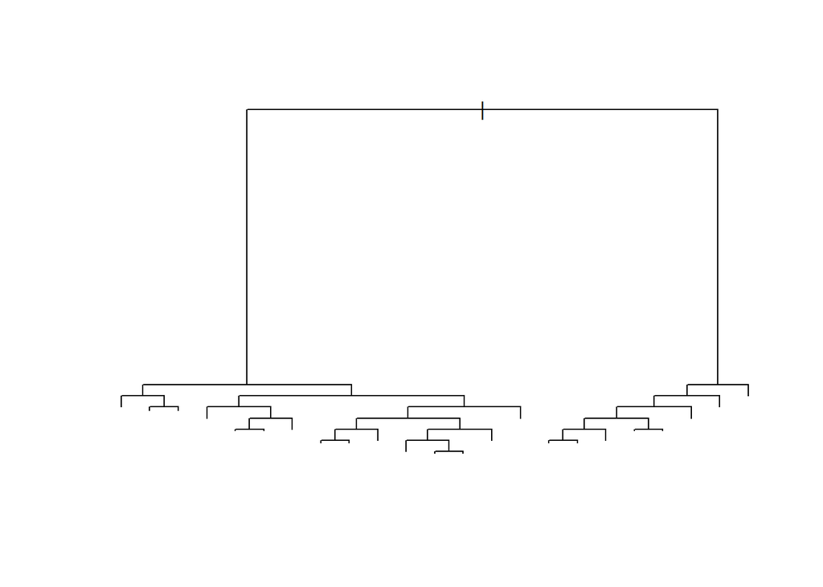

```r
plot(lcDT1bp)
```

We had a dataset which was first split into 50:50. We created a model changed the cost parameter.Then we pruned the tree with different values of cp. We also created a balanced model, later pruned the tree.

### Evalution of the model

```r
# Using the predict function, training data set




confusionM <- function(models, data) {

  predTrn=predict(models,data, type='class')
  tab1 = table(predicted = predTrn, true=data$loan_status)
  print(mean(predTrn == data$loan_status))
  return(tab1)
}

# Model with fully grown tree

# Train
confusionM(lcDT1,lcdfTrn)
```

```
## [1] 0.8757525
```

```
##              true
## predicted     Charged Off Fully Paid
##   Charged Off        1569        842
##   Fully Paid         5370      42216
```

```r
# Test

confusionM(lcDT1, lcdfTst)
```

```
## [1] 0.8372502
```

```
##              true
## predicted     Charged Off Fully Paid
##   Charged Off         605       1897
##   Fully Paid         6240      41255
```

```r
# Model with pruned tree with following p values




confusionM(lcDT1p2,lcdfTrn)
```

```
## [1] 0.8727324
```

```
##              true
## predicted     Charged Off Fully Paid
##   Charged Off        1111        535
##   Fully Paid         5828      42523
```

```r
confusionM(lcDT1p3,lcdfTrn)
```

```
## [1] 0.8612117
```

```
##              true
## predicted     Charged Off Fully Paid
##   Charged Off           0          0
##   Fully Paid         6939      43058
```

```r
# Model with balanced dataset

confusionM(lcDT1b, lcdfTrn)
```

```
## [1] 0.8146289
```

```
##              true
## predicted     Charged Off Fully Paid
##   Charged Off        6465       8794
##   Fully Paid          474      34264
```

```r
# Model balanced and pruned

confusionM(lcDT1bp, lcdfTrn)
```

```
## [1] 0.6030762
```

```
##              true
## predicted     Charged Off Fully Paid
##   Charged Off        4883      17789
##   Fully Paid         2056      25269
```

### Threshold - 0.3 from 0.5 - For all the above models

We qualified all the results above 0.5 towards charged off, we will now change the threshold to a lower value. This change is based towards our goal towards detecting Charged Off Loans well. The threshold value changes are made based on the goal you want to achieve. Trying out multiple thresholds is also an option.

```r
# 1.  Using this threshold for train and test  dataset


CTHRESH=0.3

# Using the model which is fully grown

predProbTrn=predict(lcDT1,lcdfTrn, type='prob')

predTrnCT = ifelse(predProbTrn[, 'Charged Off'] > CTHRESH, 'Charged Off', 'Fully Paid')

table(predTrnCT , true=lcdfTrn$loan_status)
```

```
##              true
## predTrnCT     Charged Off Fully Paid
##   Charged Off        2046       1673
##   Fully Paid         4893      41385
```

```r
predProbTst=predict(lcDT1,lcdfTst, type='prob')

predTstCT = ifelse(predProbTst[, 'Charged Off'] > CTHRESH, 'Charged Off', 'Fully Paid')

table(predTstCT , true=lcdfTst$loan_status)
```

```
##              true
## predTstCT     Charged Off Fully Paid
##   Charged Off         957       2869
##   Fully Paid         5888      40283
```

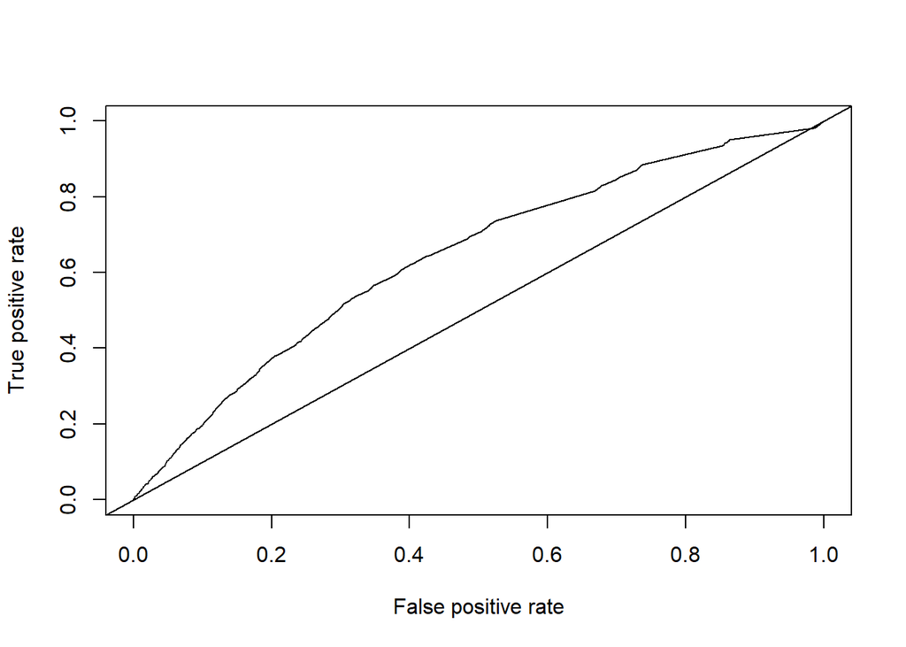

```r
# Building the roc and auc curve


score=predict(lcDT1,lcdfTst, type="prob")[,"Charged Off"]


pred=prediction(score, lcdfTst$loan_status, label.ordering = c("Fully Paid", "Charged Off"))

    #label.ordering here specifies the 'negative', 'positive' class labels
# Closer to one specifies charged off

#ROC curve

aucPerf <-performance(pred, "tpr", "fpr")

plot(aucPerf)

abline(a=0, b= 1)
```

```r
#AUC value
aucPerf=performance(pred, "auc")

aucPerf@y.values
```

```
## [[1]]
## [1] 0.6410278
```

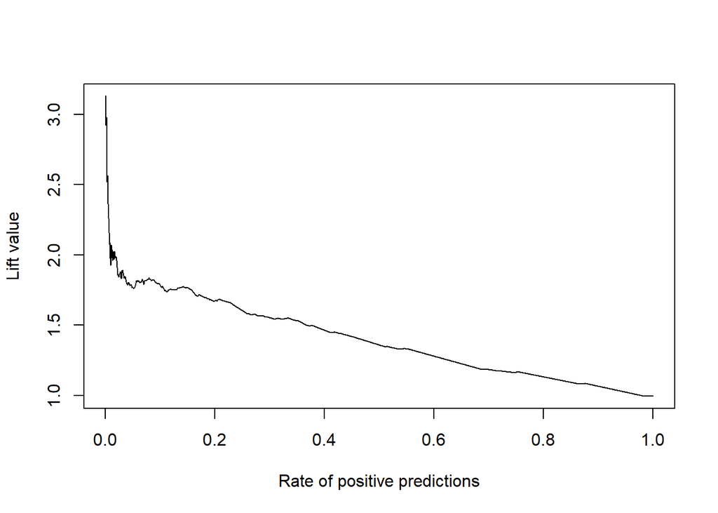

```r
# [[1]]
# [1] 0.6400753

#Lift curve
liftPerf <-performance(pred, "lift", "rpp")

plot(liftPerf)
```

```r
# 2. Using the model which were pruned - p2

predProbTrn=predict(lcDT1p2,lcdfTrn, type='prob')

predTrnCT = ifelse(predProbTrn[, 'Charged Off'] > CTHRESH, 'Charged Off', 'Fully Paid')

table(predTrnCT , true=lcdfTrn$loan_status)
```

```
##              true
## predTrnCT     Charged Off Fully Paid
##   Charged Off        1503       1216
##   Fully Paid         5436      41842
```

```r
predProbTst=predict(lcDT1p2,lcdfTst, type='prob')

predTstCT = ifelse(predProbTst[, 'Charged Off'] > CTHRESH, 'Charged Off', 'Fully Paid')

table(predTstCT , true=lcdfTst$loan_status)
```

```
##              true
## predTstCT     Charged Off Fully Paid
##   Charged Off         749       2044
##   Fully Paid         6096      41108
```

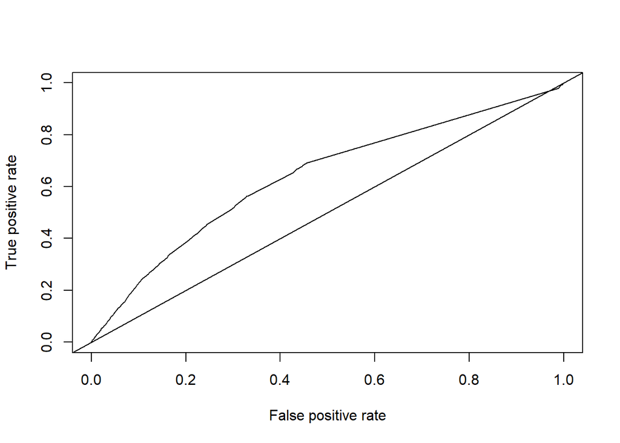

```r
# Building the roc and auc curve


score=predict(lcDT1p2,lcdfTst, type="prob")[,"Charged Off"]


pred=prediction(score, lcdfTst$loan_status, label.ordering = c("Fully Paid", "Charged Off"))

    #label.ordering here specifies the 'negative', 'positive' class labels
# Closer to one specifies charged off

#ROC curve

aucPerf <-performance(pred, "tpr", "fpr")

plot(aucPerf)

abline(a=0, b= 1)
```

```r
#AUC value
aucPerf=performance(pred, "auc")

aucPerf@y.values
```

```
## [[1]]
## [1] 0.6390247
```

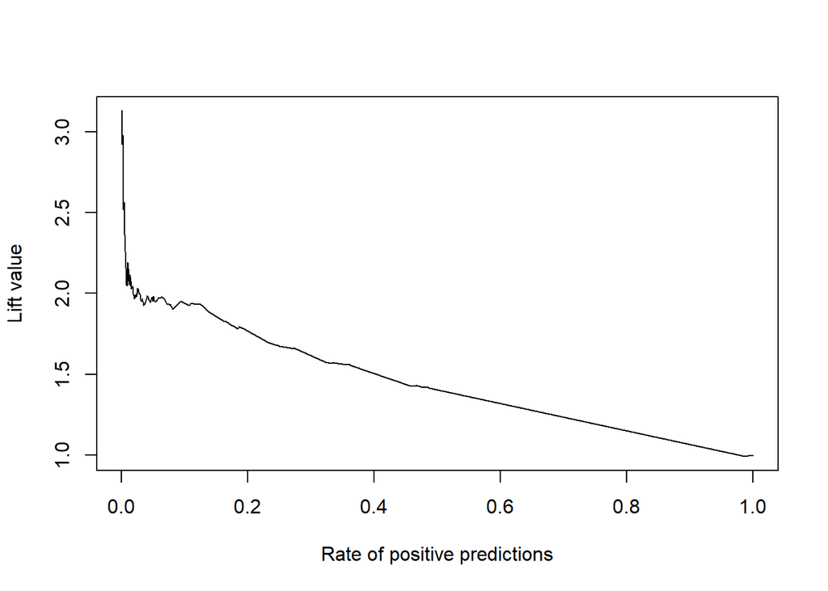

```r
# [[1]]
# [1] 0.6400753

#Lift curve
liftPerf <-performance(pred, "lift", "rpp")

plot(liftPerf)
```

```r
# 3. Using the model which were pruned - p2

predProbTrn=predict(lcDT1p3,lcdfTrn, type='prob')

predTrnCT = ifelse(predProbTrn[, 'Charged Off'] > CTHRESH, 'Charged Off', 'Fully Paid')

table(predTrnCT , true=lcdfTrn$loan_status)
```

```
##             true
## predTrnCT    Charged Off Fully Paid
##   Fully Paid        6939      43058
```

```r
predProbTst=predict(lcDT1p3,lcdfTst, type='prob')

predTstCT = ifelse(predProbTst[, 'Charged Off'] > CTHRESH, 'Charged Off', 'Fully Paid')

table(predTstCT , true=lcdfTst$loan_status)
```

```
##             true
## predTstCT    Charged Off Fully Paid
##   Fully Paid        6845      43152
```

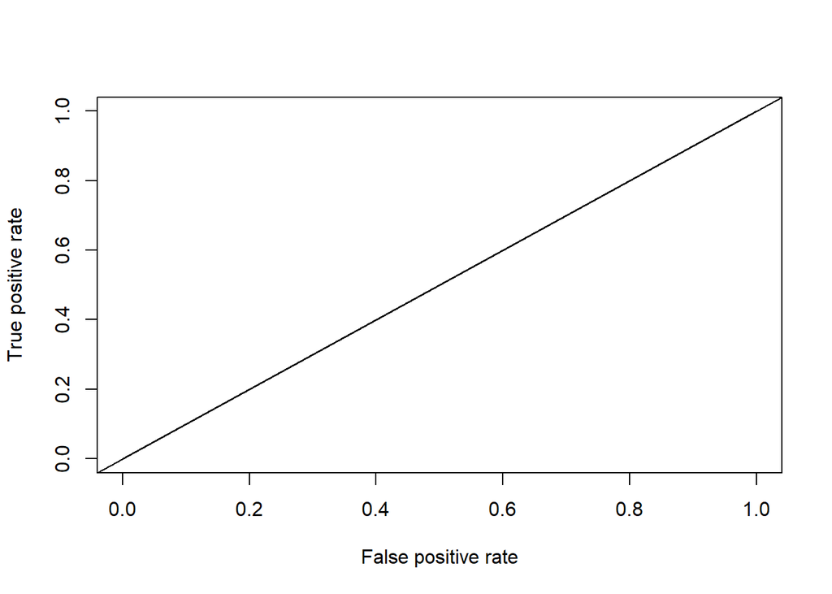

```r
# Building the roc and auc curve


score=predict(lcDT1p3,lcdfTst, type="prob")[,"Charged Off"]


pred=prediction(score, lcdfTst$loan_status, label.ordering = c("Fully Paid", "Charged Off"))

    #label.ordering here specifies the 'negative', 'positive' class labels
# Closer to one specifies charged off

#ROC curve

aucPerf <-performance(pred, "tpr", "fpr")

plot(aucPerf)

abline(a=0, b= 1)
```

```r
#AUC value
aucPerf=performance(pred, "auc")

aucPerf@y.values
```

```
## [[1]]
## [1] 0.5
```

[figure not shown]

```r
#Lift curve
liftPerf <-performance(pred, "lift", "rpp")

plot(liftPerf)
```

```r
# 4. Using the model which was balanced

predProbTrn=predict(lcDT1b,lcdfTrn, type='prob')

predTrnCT = ifelse(predProbTrn[, 'Charged Off'] > CTHRESH, 'Charged Off', 'Fully Paid')

table(predTrnCT , true=lcdfTrn$loan_status)
```

```
##              true
## predTrnCT     Charged Off Fully Paid
##   Charged Off        6738      11516
##   Fully Paid          201      31542
```

```r
predProbTst=predict(lcDT1b,lcdfTst, type='prob')

predTstCT = ifelse(predProbTst[, 'Charged Off'] > CTHRESH, 'Charged Off', 'Fully Paid')

table(predTstCT , true=lcdfTst$loan_status)
```

```
##              true
## predTstCT     Charged Off Fully Paid
##   Charged Off        3234      14897
##   Fully Paid         3611      28255
```